# Combining Machine Learning Algorithms

Agus Nur Hidayat

### Preparing packages and their dependencies

```r
install.packages("lazyeval")
install.packages("lattice")
install.packages("ggplot2")
install.packages("caret", dependencies = c("Depends", "Suggests"))
install.packages("mlbench")
install.packages("ipred")
install.packages("caretEnsemble")
```

### Loading libraries

```r
library(caret)
library(mlbench)
library(randomForest)
library(ipred)
library(caretEnsemble)
```

### Loading datasets

```r
data(Ionosphere)
dataset = Ionosphere
dataset = dataset[,-2]
dataset$V1 = as.numeric(as.character(dataset$V1))
```

### Boosting Algorithms

We can look at two of the most popular boosting machine learning algorithms:

- C5.0
- Stochastic Gradient Boosting

```r
# Example of Boosting Algorithms
trainControl = trainControl(method="repeatedcv", number=10, repeats=3)
seed = 7
metric = "Accuracy"
# C5.0
set.seed(seed)
fit.c50 = train(Class~., data=dataset, method="C5.0", metric=metric,
    trControl=trainControl)
```

```
'trials' should be <= 6 for this object. Predictions generated using 6 trials
```

```r
# Stochastic Gradient Boosting
set.seed(seed)
fit.gbm = train(Class~., data=dataset, method="gbm", metric=metric,
    trControl=trainControl, verbose=FALSE)
# summarize results
boostingResults = resamples(list(c5.0=fit.c50, gbm=fit.gbm))
summary(boostingResults)
```

```
Call:
summary.resamples(object = boostingResults)

Models: c5.0, gbm
Number of resamples: 30

Accuracy
       Min. 1st Qu. Median   Mean 3rd Qu. Max. NA's
c5.0 0.8824  0.9143 0.9437 0.9458  0.9714    1    0
gbm  0.8824  0.9143 0.9429 0.9420  0.9714    1    0

Kappa
       Min. 1st Qu. Median   Mean 3rd Qu. Max. NA's
c5.0 0.7244  0.8135 0.8745 0.8786  0.9378    1    0
gbm  0.7323  0.8135 0.8734 0.8713  0.9372    1    0
```

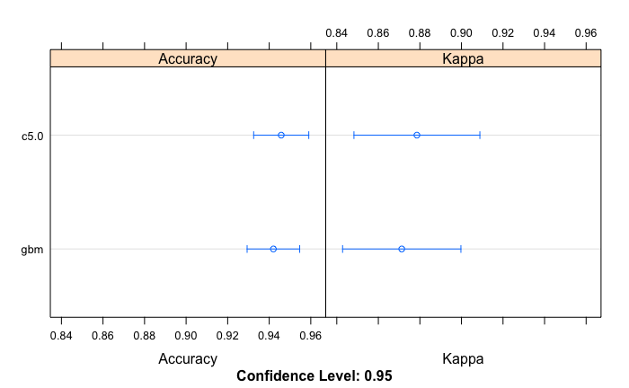

```r
dotplot(boostingResults)
```

### Bagging Algorithms

Let’s look at two of the most popular bagging machine learning algorithms:

- Bagged CART
- Random Forest

Below is an example of the Bagged CART and Random Forest algorithms in R. Both algorithms include parameters that are not tuned in this example.

```r
# Example of Bagging algorithms
trainControl = trainControl(method="repeatedcv", number=10, repeats=3)
seed = 7
metric = "Accuracy"
# Bagged CART
set.seed(seed)
fit.treebag = train(Class~., data=dataset, method="treebag", metric=metric,
    trControl=trainControl)
# Random Forest
set.seed(seed)
fit.rf = train(Class~., data=dataset, method="rf", metric=metric, trControl=trainControl)
# summarize results
baggingResults = resamples(list(treebag=fit.treebag, rf=fit.rf))
summary(baggingResults)
```

```
Call:
summary.resamples(object = baggingResults)

Models: treebag, rf
Number of resamples: 30

Accuracy
          Min. 1st Qu. Median   Mean 3rd Qu. Max. NA's
treebag 0.8235  0.8857 0.9155 0.9164  0.9444    1    0
rf      0.8571  0.9124 0.9155 0.9316  0.9444    1    0

Kappa
          Min. 1st Qu. Median   Mean 3rd Qu. Max. NA's
treebag 0.5984  0.7430 0.8118 0.8155  0.8796    1    0
rf      0.6628  0.8063 0.8179 0.8484  0.8796    1    0
```

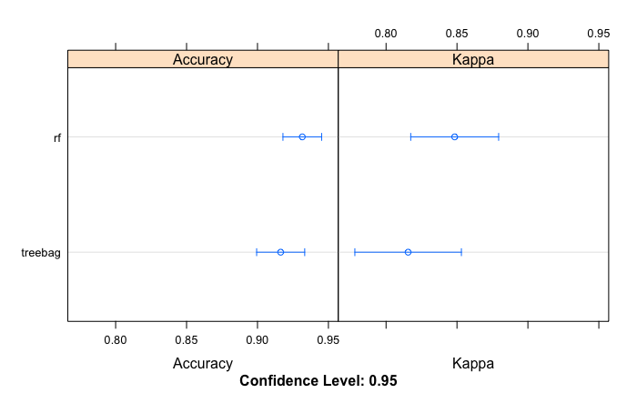

```r
dotplot(baggingResults)
```

### Stacking Algorithms

You can combine the predictions of multiple caret models using the caretEnsemble package. Given a list of caret models, the caretStack() function can be used to specify a higher-order model to learn how to best combine together the predictions of sub-models. Let’s first look at creating five sub-models for the ionosphere dataset, specifically:

- Linear Discriminate Analysis (LDA).
- Classification and Regression Trees (CART).
- Logistic Regression (via Generalized Linear Model or GLM).
- k-Nearest Neighbors (KNN).
- Support Vector Machine with a Radial Basis Kernel Function (SVM).

Below is an example that creates these five sub-models. Note the new helpful caretList() function provided by the caretEnsemble package for creating a list of standard caret models.

```r
# Example of Stacking algorithms
# create submodels
trainControl = trainControl(method="repeatedcv", number=10, repeats=3,
    savePredictions=TRUE, classProbs=TRUE)
algorithmList = c("lda", "rpart",  "glm", "knn", "svmRadial")
set.seed(seed)
models = caretList(Class~., data=dataset, trControl=trainControl, methodList=algorithmList)
```

[output not shown]

```r
results = resamples(models)
summary(results)
```

```
Call:
summary.resamples(object = results)

Models: lda, rpart, glm, knn, svmRadial
Number of resamples: 30

Accuracy
            Min. 1st Qu. Median   Mean 3rd Qu.   Max. NA's
lda       0.7714  0.8286 0.8611 0.8645  0.9060 0.9429    0
rpart     0.7714  0.8540 0.8873 0.8803  0.9143 0.9714    0
glm       0.7778  0.8286 0.8873 0.8803  0.9167 0.9722    0
knn       0.7647  0.8056 0.8431 0.8451  0.8857 0.9167    0
svmRadial 0.8824  0.9143 0.9429 0.9486  0.9722 1.0000    0

Kappa
            Min. 1st Qu. Median   Mean 3rd Qu.   Max. NA's
lda       0.4595  0.5746 0.6810 0.6809  0.7852 0.8712    0
rpart     0.4776  0.6619 0.7490 0.7346  0.8127 0.9378    0
glm       0.5017  0.6144 0.7572 0.7316  0.8163 0.9388    0
knn       0.3929  0.5364 0.6353 0.6327  0.7330 0.8099    0
svmRadial 0.7244  0.8144 0.8778 0.8873  0.9405 1.0000    0
```

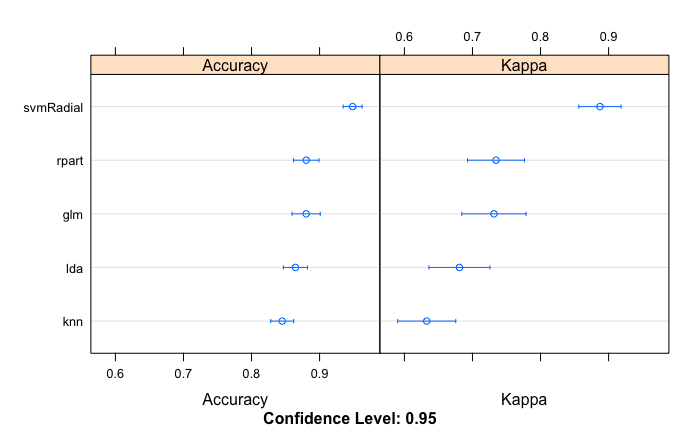

```r
dotplot(results)
```

When we combine the predictions of different models using stacking, it is desirable that the predictions made by the sub-models have low correlation. This would suggest that the models are skillful but in different ways, allowing a new classifier to figure out how to get the best from each model for an improved score. If the predictions for the sub-models were highly corrected (> 0.75) then they would be making the same or very similar predictions most of the time reducing the benefit of combining the predictions.

```r
# correlation between results
modelCor(results)
```

```
                lda     rpart       glm       knn svmRadial
lda       1.0000000 0.2515454 0.2970731 0.5013524 0.1790091
rpart     0.2515454 1.0000000 0.1749923 0.2823324 0.2938493
glm       0.2970731 0.1749923 1.0000000 0.5172239 0.4270294
knn       0.5013524 0.2823324 0.5172239 1.0000000 0.3973669
svmRadial 0.1790091 0.2938493 0.4270294 0.3973669 1.0000000
```

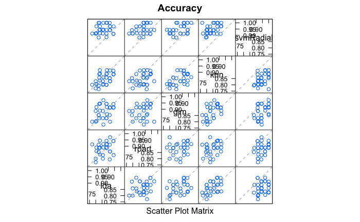

```r
splom(results)
```

We can see that all pairs of predictions have generally low correlation. The two methods with the highest correlation between their predictions are Logistic Regression (GLM) and KNN at 0.517 correlation which is not considered high (> 0.75). Let’s combine the predictions of the classifiers using a simple linear model.

```r
# stack using glm
stackControl = trainControl(method="repeatedcv", number=10, repeats=3,
    savePredictions=TRUE, classProbs=TRUE)
set.seed(seed)
stack.glm = caretStack(models, method="glm", metric="Accuracy", trControl=stackControl)
print(stack.glm)
```

```
A glm ensemble of 2 base models: lda, rpart, glm, knn, svmRadial

Ensemble results:
Generalized Linear Model

1053 samples
   5 predictor
   2 classes: 'bad', 'good'

No pre-processing
Resampling: Cross-Validated (10 fold, repeated 3 times)
Summary of sample sizes: 948, 947, 948, 947, 949, 948, ...
Resampling results:

  Accuracy   Kappa
  0.9509305  0.893296
```

We can also use more sophisticated algorithms to combine predictions in an effort to tease out when best to use the different methods. In this case, we use the Random Forest algorithm to combine the predictions.

```r
# stack using random forest
set.seed(seed)
stack.rf = caretStack(models, method="rf", metric="Accuracy", trControl=stackControl)
print(stack.rf)
```

```
A rf ensemble of 2 base models: lda, rpart, glm, knn, svmRadial

Ensemble results:
Random Forest

1053 samples
   5 predictor
   2 classes: 'bad', 'good'

No pre-processing
Resampling: Cross-Validated (10 fold, repeated 3 times)
Summary of sample sizes: 948, 947, 948, 947, 949, 948, ...
Resampling results across tuning parameters:

  mtry  Accuracy   Kappa
  2     0.9578969  0.9078746
  3     0.9556745  0.9030845
  5     0.9550365  0.9018594

Accuracy was used to select the optimal model using  the largest value.
The final value used for the model was mtry = 2.
```